# Babynames

Damilare Olaleye

10/8/2019

The data frame babynames has five variables:

- year
- sex
- name
- n
- prop (n divided by the total number of applicants in that year).

To get started, download this package from CRAN using the install.packages command. Load the package in the Markdown document using the library function.

1. First check out the popularity of your given first name.
- Create a new data frame consisting only the year and prop variables for your name (use the select and filter functions from the dplyr package).
- Use a scatterplot to plot the year against prop for your name
- Summarize what you learn from the graph.

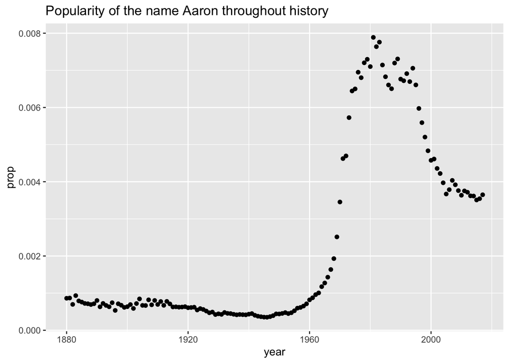

```r
#install.packages("babynames")
library(babynames)
library(tidyverse)
#Assuming name Aaron
babynames %>% filter(name == "Aaron", sex == "M") %>% select(year, prop) -> bName
ggplot(bName, aes(year, prop)) + geom_point() + ggtitle("Popularity of the name Aaron throughout history")
```

2. Repeat number 1 for your mother’s first name and your father’s first name. Summarize what you have learned about the popularity of your mother’s and your father’s name over time.

#Assume Chester, Emma

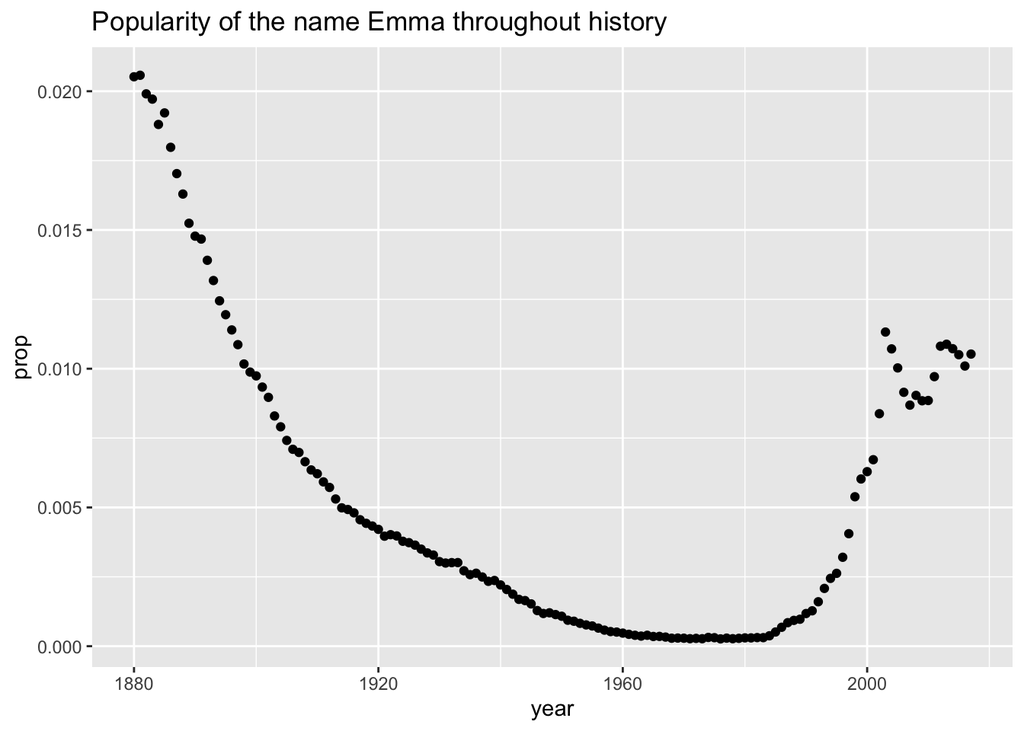

```r
filter(babynames, name == "Chester", sex == "M") %>% select(name, year, prop ) -> papName
filter(babynames, name == "Emma", sex == "F") %>% select(name, year, prop ) -> mumName

ggplot() + geom_point(data = mumName, aes(year,prop)) + ggtitle("Popularity of the name Emma throughout history")
```

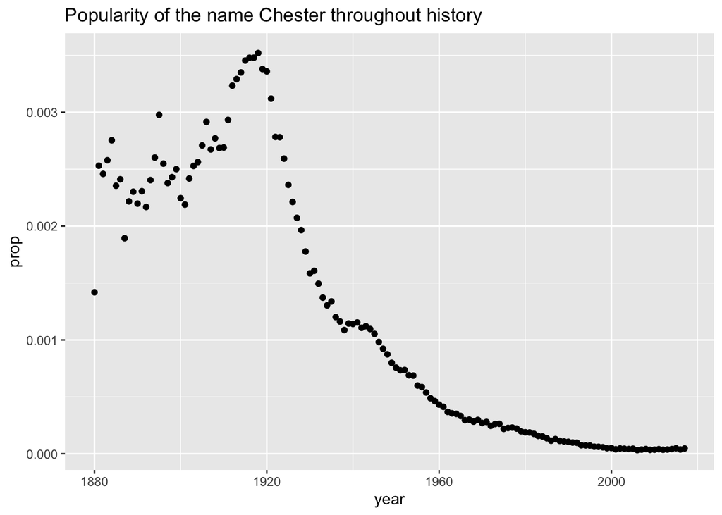

```r
ggplot() + geom_point(data = papName, aes(year,prop)) + ggtitle("Popularity of the name Chester throughout history")
```

3. For your birthyear, create two tables – one showing the 10 most popular boy names, and second table showing the 10 most popular girl names for your birthyear.

```r
bYear <- babynames %>% filter(year == 1996, sex == "M") %>% select(name, n) %>% arrange(sort(n, decreasing = F))
gYear <- babynames %>% filter(year == 1996, sex == "F") %>% select(name, n) %>% arrange(sort(n))
slice(bYear, 1:10)
```

```
## # A tibble: 10 x 2
##    name            n
##    <chr>       <int>
##  1 Michael     38365
##  2 Matthew     32073
##  3 Jacob       31923
##  4 Christopher 30902
##  5 Joshua      29169
##  6 Nicholas    27720
##  7 Tyler       26953
##  8 Brandon     25845
##  9 Austin      25660
## 10 Andrew      25234
```

```r
slice(gYear, 1:10)
```

```
## # A tibble: 10 x 2
##    name          n
##    <chr>     <int>
##  1 Emily     25151
##  2 Jessica   24194
##  3 Ashley    23677
##  4 Sarah     21036
##  5 Samantha  20548
##  6 Taylor    19151
##  7 Hannah    18595
##  8 Alexis    16589
##  9 Rachel    16115
## 10 Elizabeth 15995
```

4. Use the mutate function to create a new variable firstletter that is the first letter of the name. If you are female, find the most popular first letter for girl names in 1960 and the most popular first letter for girl names in 2000. (If you are male, do the same thing for boy names.)

```r
babynames %>% filter(year == 1960, sex == "M") %>% mutate(firstLetter = substr(name, 1, 1)) %>% select(firstLetter, n) %>% group_by(firstLetter) %>% summarise(total = sum(n)) %>% arrange(desc(total)) -> firstLetter1960
babynames %>% filter(year == 2000, sex == "M") %>% mutate(firstLetter = substr(name, 1, 1)) %>% select(firstLetter, n) %>% group_by(firstLetter) %>% summarise(total = sum(n)) %>% arrange(desc(total)) -> firstLetter2000

slice(firstLetter1960, 1:10)
```

```
## # A tibble: 10 x 2
##    firstLetter  total
##    <chr>        <int>
##  1 J           318764
##  2 R           263513
##  3 D           240900
##  4 M           208239
##  5 T           135051
##  6 S           112974
##  7 C           111161
##  8 K            96895
##  9 G            96497
## 10 B            95396
```

```r
slice(firstLetter2000, 1:10)
```

```
## # A tibble: 10 x 2
##    firstLetter  total
##    <chr>        <int>
##  1 J           341754
##  2 A           187196
##  3 C           176185
##  4 D           160305
##  5 M           140313
##  6 B           107016
##  7 T           104853
##  8 R            91733
##  9 S            87993
## 10 E            80672
```

5. Use a graph to compare the popularity of the two first letters who found in part 4 over time. Explain what you have learned about the relative popularity of these two first letters.

```r
slice(firstLetter1960, 1:10)
```

```
## # A tibble: 10 x 2
##    firstLetter  total
##    <chr>        <int>
##  1 J           318764
##  2 R           263513
##  3 D           240900
##  4 M           208239
##  5 T           135051
##  6 S           112974
##  7 C           111161
##  8 K            96895
##  9 G            96497
## 10 B            95396
```

```r
slice(firstLetter2000, 1:10)
```

```
## # A tibble: 10 x 2
##    firstLetter  total
##    <chr>        <int>
##  1 J           341754
##  2 A           187196
##  3 C           176185
##  4 D           160305
##  5 M           140313
##  6 B           107016
##  7 T           104853
##  8 R            91733
##  9 S            87993
## 10 E            80672
```

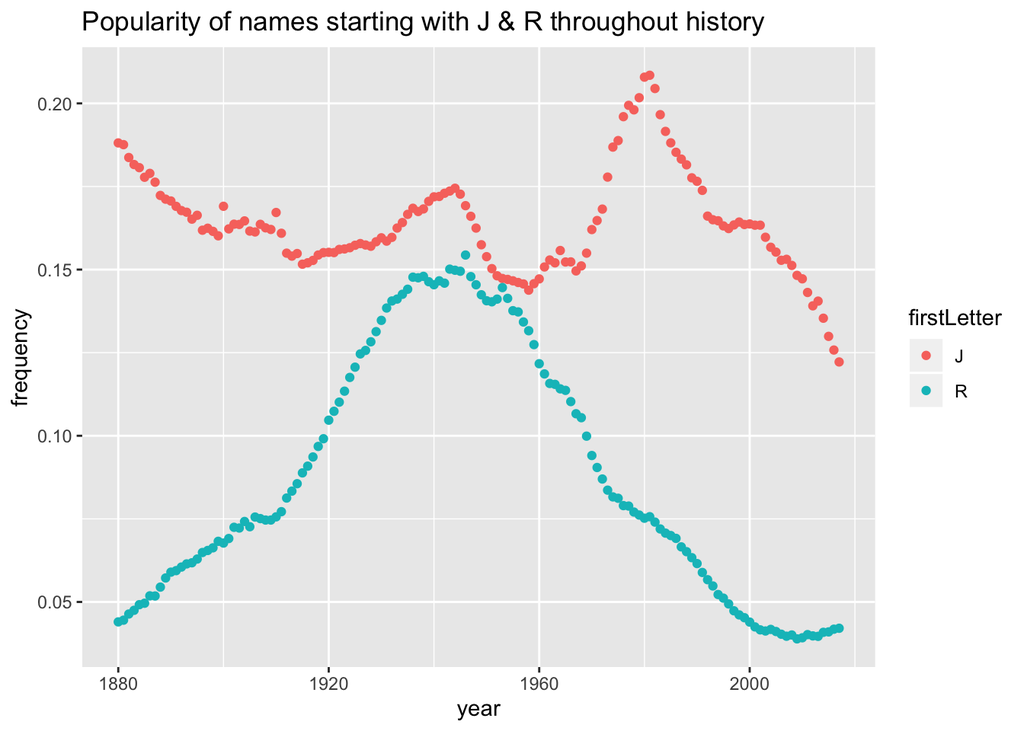

```r
# Using R as the other popular first letter since J is the most popular first letter in both cases
babynames %>% mutate(firstLetter = substr(name, 1, 1)) %>% filter(firstLetter == "R" | firstLetter == "J", sex == "M") %>%  group_by(year, firstLetter) %>% summarise(frequency = sum(prop)) -> popFirstLetter

ggplot(popFirstLetter) + geom_point(mapping = aes(year, frequency, color = firstLetter)) + ggtitle("Popularity of names starting with J & R throughout history")
```